# Machine Learning Analysis of Productivity Determinants using Behavioral Data

Faculty of Mathematics

Andrija Radojević

# Productivity: Key Influencing Factors and Model Robustness

We investigate the key behavioral and psychological factors that predict individual productivity and evaluate the robustness of linear and regularized regression models under cross-validation.

Data preparation

```r
#loading dataset and reading first few lines

library(dplyr)
library(data.table)
a<- fread("ScreenTime vs MentalWellness.csv")

head(a)
```

```
##    user_id   age           gender    occupation work_mode screen_time_hours
##     <char> <int>           <char>        <char>    <char>             <num>
## 1:   U0001    33           Female      Employed    Remote             10.79
## 2:   U0002    28           Female      Employed In-person              7.40
## 3:   U0003    35           Female      Employed    Hybrid              9.78
## 4:   U0004    42             Male      Employed    Hybrid             11.13
## 5:   U0005    28             Male       Student    Remote             13.22
## 6:   U0006    28 Non-binary/Other Self-employed    Hybrid              9.83
##    work_screen_hours leisure_screen_hours sleep_hours sleep_quality_1_5
##                <num>                <num>       <num>             <int>
## 1:              5.44                 5.35        6.63                 1
## 2:              0.37                 7.03        8.05                 3
## 3:              1.09                 8.69        6.48                 1
## 4:              0.56                10.57        6.89                 1
## 5:              4.09                 9.13        5.79                 1
```

[output cut: 17 more lines]

```r
summary(a)             #descriptive statistics
```

```
##    user_id               age           gender           occupation
##  Length:400         Min.   :16.00   Length:400         Length:400
##  Class :character   1st Qu.:24.00   Class :character   Class :character
##  Mode  :character   Median :30.00   Mode  :character   Mode  :character
##                     Mean   :29.78
##                     3rd Qu.:35.00
##                     Max.   :60.00
##   work_mode         screen_time_hours work_screen_hours leisure_screen_hours
##  Length:400         Min.   : 1.000    Min.   : 0.110    Min.   : 0.890
##  Class :character   1st Qu.: 7.372    1st Qu.: 0.695    1st Qu.: 5.460
##  Mode  :character   Median : 9.090    Median : 1.455    Median : 6.700
##                     Mean   : 9.025    Mean   : 2.183    Mean   : 6.842
##                     3rd Qu.:10.495    3rd Qu.: 3.013    3rd Qu.: 8.418
##                     Max.   :19.170    Max.   :12.040    Max.   :13.350
##   sleep_hours    sleep_quality_1_5 stress_level_0_10 productivity_0_100
##  Min.   :4.640   Min.   :1.000     Min.   : 0.00     Min.   : 20.60
##  1st Qu.:6.397   1st Qu.:1.000     1st Qu.: 6.90     1st Qu.: 43.60
##  Median :7.030   Median :1.000     Median : 8.80     Median : 51.75
##  Mean   :7.013   Mean   :1.397     Mean   : 8.15     Mean   : 54.31
##  3rd Qu.:7.640   3rd Qu.:2.000     3rd Qu.:10.00     3rd Qu.: 63.00
##  Max.   :9.740   Max.   :4.000     Max.   :10.00     Max.   :100.00
##  exercise_minutes_per_week social_hours_per_week mental_wellness_index_0_100
##  Min.   :  0.0             Min.   : 0.000        Min.   : 0.000
##  1st Qu.: 58.0             1st Qu.: 4.575        1st Qu.: 3.675
##  Median :103.0             Median : 7.750        Median :14.800
##  Mean   :109.8             Mean   : 7.905        Mean   :20.327
##  3rd Qu.:157.0             3rd Qu.:11.025        3rd Qu.:30.650
##  Max.   :372.0             Max.   :23.900        Max.   :97.000
##    V16
##  Mode:logical
##  NA's:400
##
##
##
##
```

```r
b<- a %>%
  select(where(~ !all(is.na(.))))                          #deleting NA

b<-b%>% select(-user_id)                                    #deleting column user_id
attach(b)
```

```r
#converting categorical variables to factors
age<-as.factor(age)
occupation<-as.factor(occupation)
gender<-as.factor(gender)
work_mode<-as.factor(work_mode)
```

We will try fitting the first model. For the first three models, we will select predictors that seem the most interesting and most strongly related to productivity.

Exploratory Data Analysis

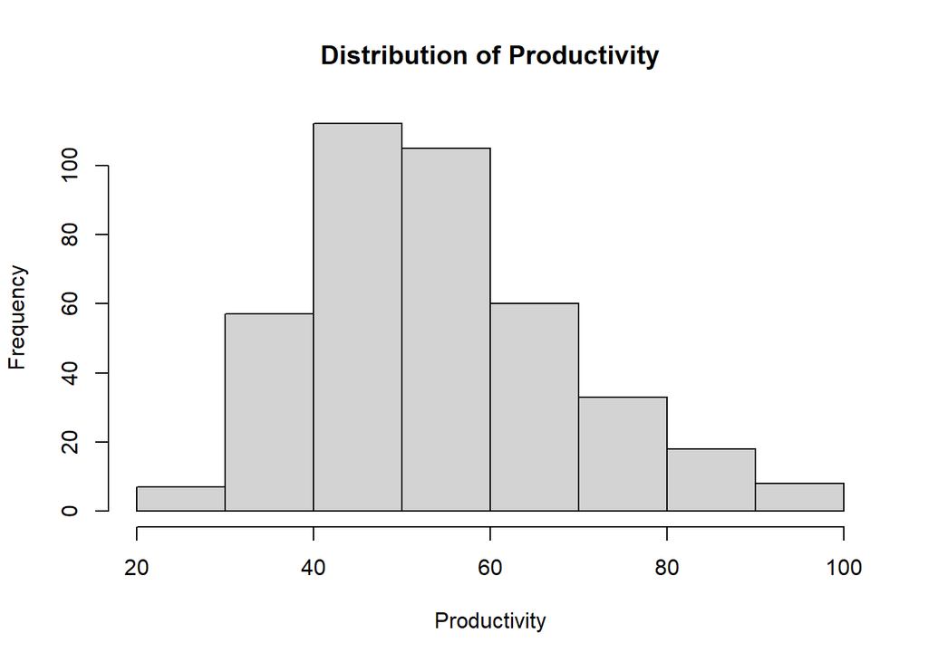

```r
hist(b$productivity_0_100, main="Distribution of Productivity", xlab="Productivity")
```

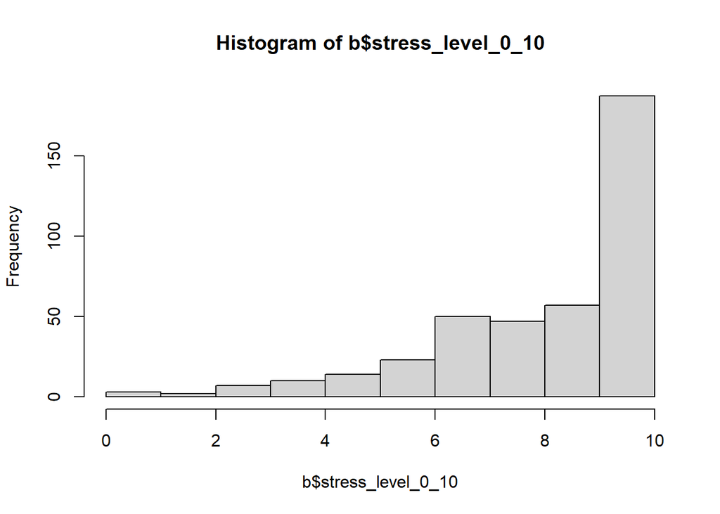

```r
hist(b$stress_level_0_10)
```

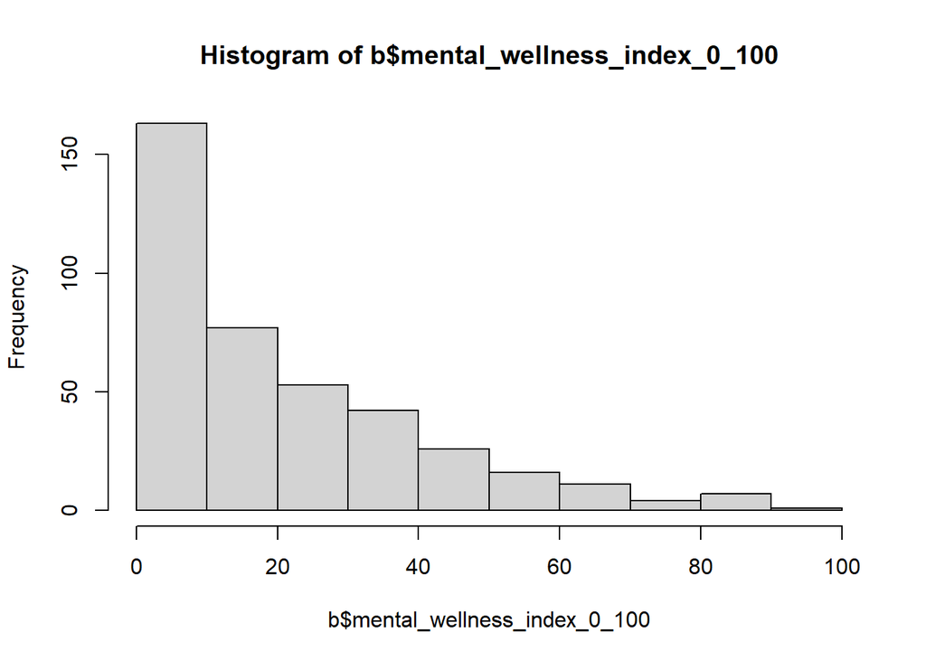

```r
hist(b$mental_wellness_index_0_100)
```

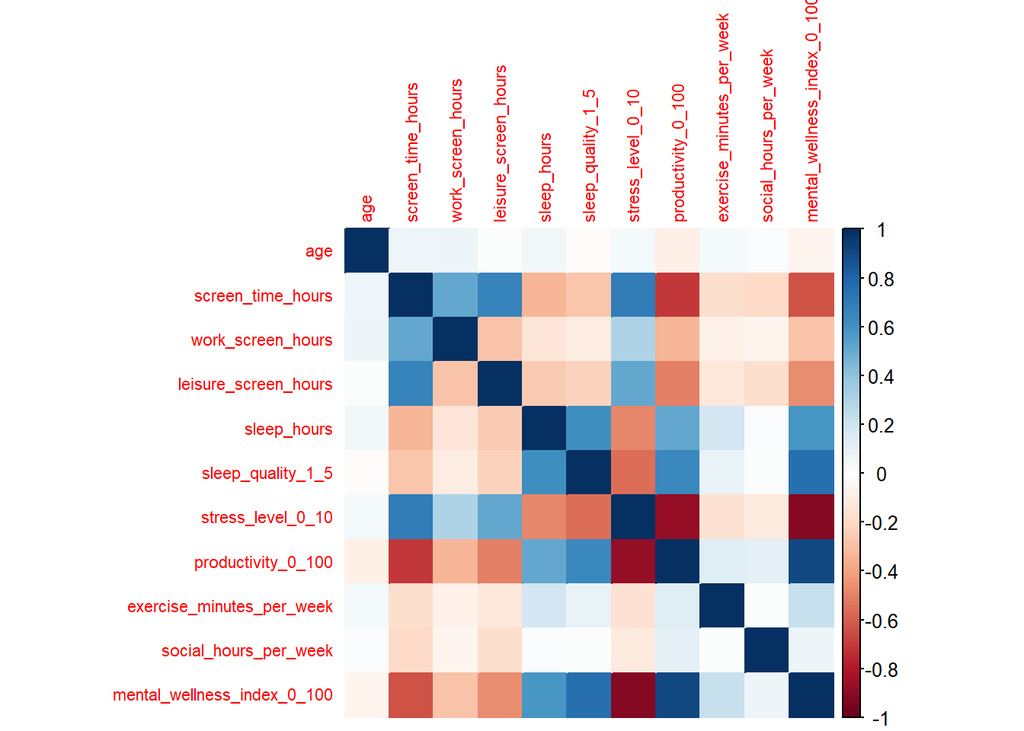

```r
library(corrplot)                           #correlation matrix

num_vars <- b %>% select_if(is.numeric)
cor_mat <- cor(num_vars)

corrplot(cor_mat, method="color", tl.cex=0.7)
```

This correlation matrix reveals the relationships between behavioral, lifestyle, and wellness variables. Strong positive correlations are observed between screen_time_hours and its components (work_screen_hours and leisure_screen_hours), while stress_level_0_10 shows a strong negative correlation with mental_wellness_index_0_100, indicating higher stress is associated with lower mental wellness. Additionally, sleep_hours is positively correlated with sleep_quality_1_5 and moderately negatively correlated with stress_level_0_10, suggesting better sleep supports lower stress. Overall, these patterns highlight key behavioral factors influencing mental wellness, providing a foundation for predictive modeling or intervention analysis.

Baseline linear specification

The analysis follows a structured machine learning pipeline. Models are evaluated using cross-validated RMSE to ensure generalization, and developed in a sequential manner from feature exploration to a final regularized specification.

Model 1

```r
#our goal is to fit best lm model

#We will use cross-validation to determine which model has the best metrics, and then we will evaluate it on the test set

N<-nrow(b)

set.seed(123)
library(caret)


train_index <- createDataPartition(b$productivity_0_100, p = 0.8, list = FALSE)
train_data <- b[train_index, ]
test_data  <- b[-train_index, ]



train_control <- trainControl(method = "cv", number = 10,savePredictions = "all")   #function from caret

#We train a linear model using cross-validation
model1 <- train(
  productivity_0_100~stress_level_0_10+sleep_quality_1_5,
  data = train_data,
  method = "lm",
  trControl = train_control,
  metric = "RMSE"
)
summary(model1)
```

```
##
## Call:
## lm(formula = .outcome ~ ., data = dat)
##
## Residuals:
##      Min       1Q   Median       3Q      Max
## -21.7483  -4.3483   0.2637   4.4729  18.1733
##
## Coefficients:
##                   Estimate Std. Error t value Pr(>|t|)
## (Intercept)        91.0516     2.3381   38.94  < 2e-16 ***
## stress_level_0_10  -5.4097     0.2053  -26.36  < 2e-16 ***
## sleep_quality_1_5   5.3933     0.6923    7.79 9.48e-14 ***
## ---
## Signif. codes:  0 '***' 0.001 '**' 0.01 '*' 0.05 '.' 0.1 ' ' 1
##
## Residual standard error: 6.571 on 319 degrees of freedom
## Multiple R-squared:  0.8051, Adjusted R-squared:  0.8039
## F-statistic: 658.9 on 2 and 319 DF,  p-value: < 2.2e-16
```

```r
#Looking at the cross-validation results
model1$results
```

```
##   intercept     RMSE  Rsquared      MAE   RMSESD RsquaredSD     MAESD
## 1      TRUE 6.514127 0.8034252 5.150338 1.093353 0.08422632 0.7884764
```

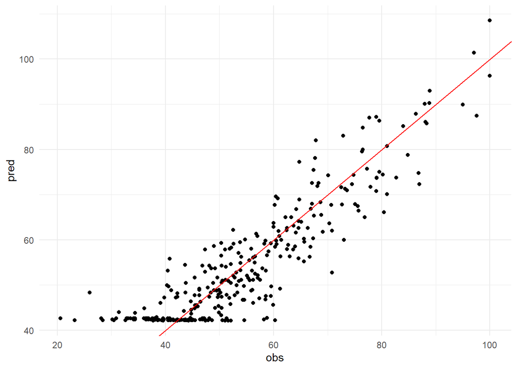

```r
pred_df <- model1$pred
ggplot(pred_df, aes(x=obs, y=pred)) +
  geom_point() +
  geom_abline(slope=1, intercept=0, color="red") +
  theme_minimal()
```

We examine this summary for the coefficients, while below we have the metrics that will be used to compare with subsequent models. Both predictors appear to be significant for the outcome, as indicated by the three stars and low p-values. Stress level has a negative effect on productivity, whereas sleep quality has a positive effect, which aligns with expectations.

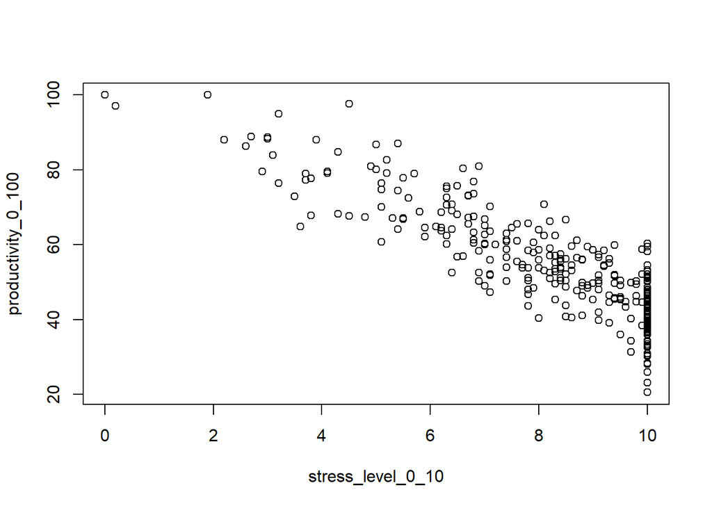

```r
plot(productivity_0_100~stress_level_0_10,data=train_data)
```

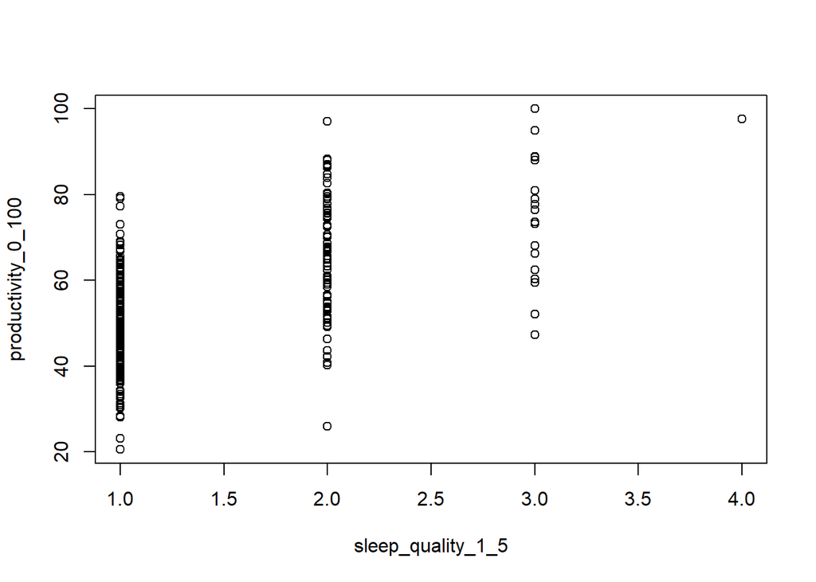

```r
plot(productivity_0_100~sleep_quality_1_5,data=train_data)
```

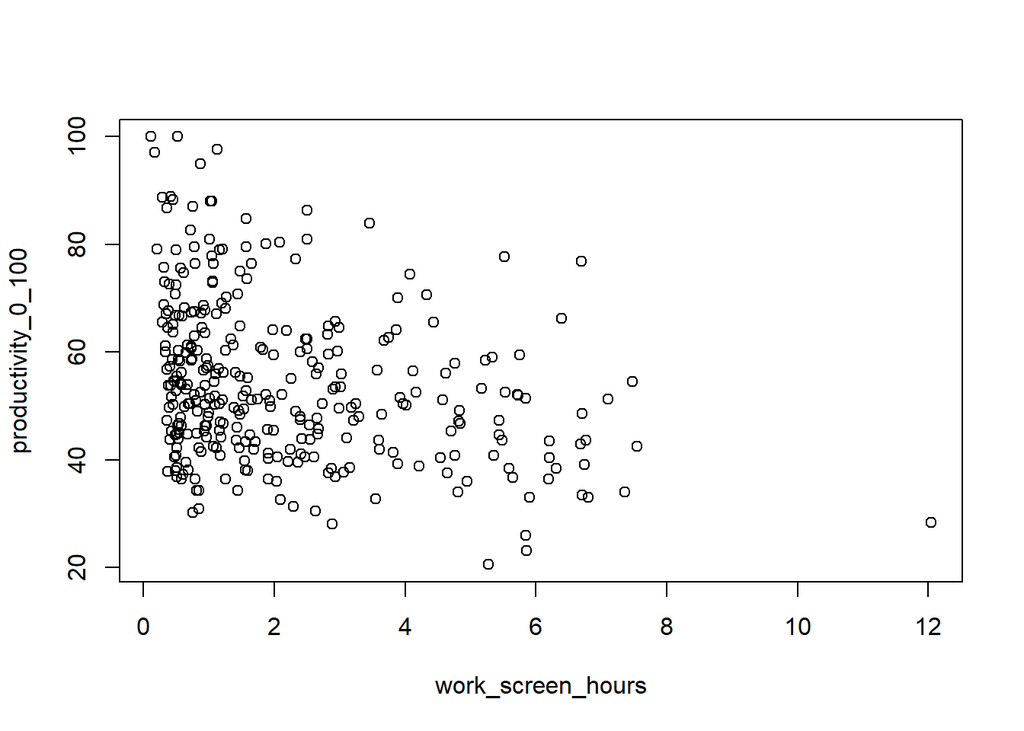

```r
plot(productivity_0_100~work_screen_hours,data=train_data)
```

We plot these scatterplots to assess whether the selected factors exhibit a linear relationship with the dependent variable before including them in the model.

Model 2

```r
set.seed(123)

train_control <- trainControl(method = "cv", number = 10,savePredictions = "all")   #function from caret

# We train a linear model using cross-validation
model2 <- train(
  productivity_0_100~stress_level_0_10+sleep_quality_1_5+work_screen_hours,
  data = train_data,
  method = "lm",
  trControl = train_control,
  metric = "RMSE"
)
summary(model2)
```

```
##
## Call:
## lm(formula = .outcome ~ ., data = dat)
##
## Residuals:
##      Min       1Q   Median       3Q      Max
## -20.2039  -4.5118   0.1019   4.3354  17.8352
##
## Coefficients:
##                   Estimate Std. Error t value Pr(>|t|)
## (Intercept)        90.4965     2.3188  39.027  < 2e-16 ***
## stress_level_0_10  -5.2201     0.2130 -24.503  < 2e-16 ***
## sleep_quality_1_5   5.5942     0.6878   8.134 9.43e-15 ***
## work_screen_hours  -0.5856     0.2008  -2.917  0.00379 **
## ---
## Signif. codes:  0 '***' 0.001 '**' 0.01 '*' 0.05 '.' 0.1 ' ' 1
##
## Residual standard error: 6.495 on 318 degrees of freedom
## Multiple R-squared:  0.8102, Adjusted R-squared:  0.8084
## F-statistic: 452.5 on 3 and 318 DF,  p-value: < 2.2e-16
```

```r
#Looking at the cross-validation results
model2$results
```

```
##   intercept     RMSE  Rsquared      MAE    RMSESD RsquaredSD     MAESD
## 1      TRUE 6.464593 0.8050507 5.108424 0.9762845 0.07350744 0.7607567
```

We observe that the plot does not show a pronounced linear relationship for the working_hours variable, yet the model summary suggests otherwise.

Model 3

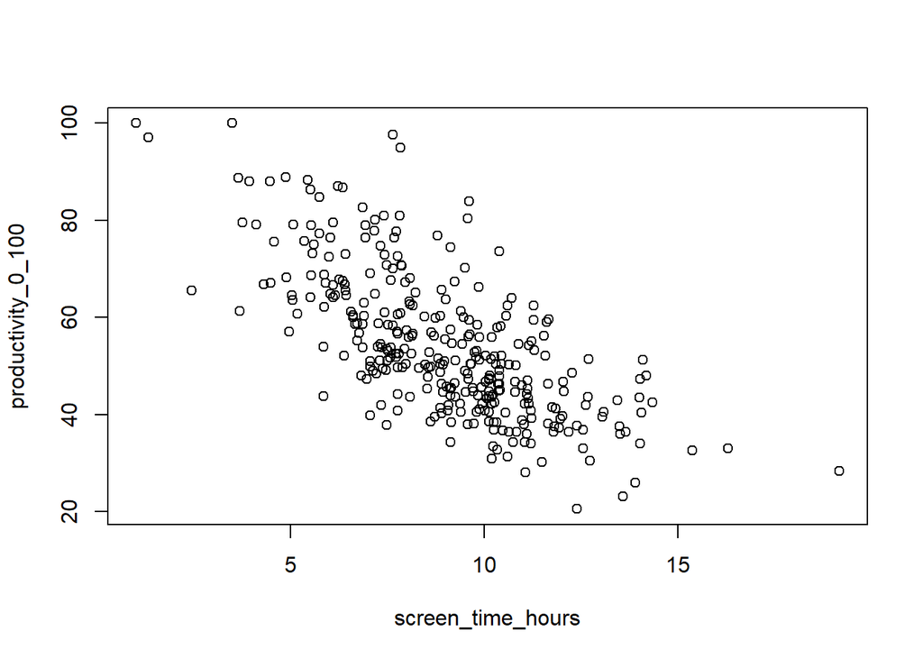

```r
library(car)

plot(productivity_0_100~screen_time_hours,data=train_data)
```

```r
set.seed(123)

train_control <- trainControl(method = "cv", number = 10,savePredictions = "all")   #function from caret

#We train a linear model using cross-validation
model3 <- train(
  productivity_0_100~stress_level_0_10+sleep_quality_1_5+screen_time_hours,
  data = train_data,
  method = "lm",
  trControl = train_control,
  metric = "RMSE"
)

summary(model3)
```

```
##
## Call:
## lm(formula = .outcome ~ ., data = dat)
##
## Residuals:
##      Min       1Q   Median       3Q      Max
## -19.1734  -4.0429  -0.2037   4.5605  17.0645
##
## Coefficients:
##                   Estimate Std. Error t value Pr(>|t|)
## (Intercept)        91.7610     2.1897  41.905  < 2e-16 ***
## stress_level_0_10  -4.1663     0.2648 -15.734  < 2e-16 ***
## sleep_quality_1_5   6.1757     0.6577   9.389  < 2e-16 ***
## screen_time_hours  -1.3318     0.1953  -6.819 4.61e-11 ***
## ---
## Signif. codes:  0 '***' 0.001 '**' 0.01 '*' 0.05 '.' 0.1 ' ' 1
##
## Residual standard error: 6.147 on 318 degrees of freedom
## Multiple R-squared:   0.83,  Adjusted R-squared:  0.8284
## F-statistic: 517.5 on 3 and 318 DF,  p-value: < 2.2e-16
```

```r
#Looking at the cross-validation results
model3$results
```

```
##   intercept    RMSE  Rsquared      MAE    RMSESD RsquaredSD     MAESD
## 1      TRUE 6.11544 0.8273368 4.890379 0.9608305 0.06213451 0.7320721
```

We add a new variable, screen_time_hours, which also appears to be highly significant (three stars). However, we will now adopt a more precise approach: we will fit a model including all variables and then remove them sequentially to arrive at the best model.

Feature selection and model refinement

Model 4

```r
#with all predictors now
set.seed(123)
train_control <- trainControl(method = "cv", number = 10,savePredictions = "all")   #function from caret

# We train a linear model using cross-validation
model4 <- train(
  productivity_0_100~.,
  data = train_data,
  method = "lm",
  trControl = train_control,
  metric = "RMSE"
)
summary(model4)
```

```
##
## Call:
## lm(formula = .outcome ~ ., data = dat)
##
## Residuals:
##      Min       1Q   Median       3Q      Max
## -17.2606  -3.7458  -0.2813   3.6983  17.1874
##
## Coefficients: (1 not defined because of singularities)
##                              Estimate Std. Error t value Pr(>|t|)
## (Intercept)                 65.905997   5.493053  11.998  < 2e-16 ***
## age                         -0.029138   0.045464  -0.641 0.522070
## genderMale                   0.359336   0.671817   0.535 0.593130
## `genderNon-binary/Other`    -2.408453   2.353478  -1.023 0.306952
## occupationRetired            1.122074   1.837549   0.611 0.541897
## `occupationSelf-employed`    2.779094   1.052377   2.641 0.008699 **
## occupationStudent            0.842745   0.829586   1.016 0.310503
## occupationUnemployed         0.643991   1.389451   0.463 0.643348
## `work_modeIn-person`         0.011241   0.844651   0.013 0.989390
## work_modeRemote             -1.280132   1.132901  -1.130 0.259384
## screen_time_hours           -1.093781   0.225101  -4.859 1.89e-06 ***
## work_screen_hours            0.199076   0.311225   0.640 0.522879
## leisure_screen_hours               NA         NA      NA       NA
## sleep_hours                  0.346875   0.499966   0.694 0.488340
## sleep_quality_1_5            1.398170   0.961319   1.454 0.146859
## stress_level_0_10           -1.607994   0.455120  -3.533 0.000474 ***
## exercise_minutes_per_week   -0.014957   0.005049  -2.962 0.003296 **
## social_hours_per_week        0.083106   0.069087   1.203 0.229944
## mental_wellness_index_0_100  0.403446   0.059756   6.752 7.42e-11 ***
## ---
## Signif. codes:  0 '***' 0.001 '**' 0.01 '*' 0.05 '.' 0.1 ' ' 1
##
## Residual standard error: 5.773 on 304 degrees of freedom
## Multiple R-squared:  0.8566, Adjusted R-squared:  0.8486
## F-statistic: 106.8 on 17 and 304 DF,  p-value: < 2.2e-16
```

```r
#Looking at the cross-validation results
model4$results
```

```
##   intercept     RMSE  Rsquared      MAE    RMSESD RsquaredSD     MAESD
## 1      TRUE 5.921867 0.8375426 4.785857 0.8232557 0.05219179 0.6992509
```

We already observe a higher R², along with lower RMSE and MAE. However, many predictors are not directly related to, nor do they have a significant effect on, the dependent variable. Therefore, we will remove them to improve the model and reduce variance.

Model 5

```r
#We will now remove leisure and the other variables one by one until only the important variables remain

set.seed(123)

train_control <- trainControl(method = "cv", number = 10,savePredictions = "all")   #function from caret

#We train a linear model using cross-validation
model5 <- train(
  productivity_0_100~ . -leisure_screen_hours - work_screen_hours - sleep_hours - social_hours_per_week - age - gender - work_mode,
  data = train_data,
  method = "lm",
  trControl = train_control,
  metric = "RMSE"
)
summary(model5)
```

```
##
## Call:
## lm(formula = .outcome ~ ., data = dat)
##
## Residuals:
##      Min       1Q   Median       3Q      Max
## -17.3049  -3.8292  -0.2999   3.8410  17.0018
##
## Coefficients:
##                              Estimate Std. Error t value Pr(>|t|)
## (Intercept)                 69.205561   4.131747  16.750  < 2e-16 ***
## occupationRetired            0.188281   1.739735   0.108 0.913888
## `occupationSelf-employed`    2.691914   1.036471   2.597 0.009844 **
## occupationStudent            0.773273   0.807800   0.957 0.339178
## occupationUnemployed         0.687877   1.358561   0.506 0.612984
## screen_time_hours           -1.149933   0.193848  -5.932 7.94e-09 ***
## sleep_quality_1_5            1.798381   0.898836   2.001 0.046281 *
## stress_level_0_10           -1.698412   0.446715  -3.802 0.000173 ***
## exercise_minutes_per_week   -0.015181   0.005003  -3.035 0.002611 **
## mental_wellness_index_0_100  0.391100   0.058506   6.685 1.07e-10 ***
## ---
## Signif. codes:  0 '***' 0.001 '**' 0.01 '*' 0.05 '.' 0.1 ' ' 1
##
## Residual standard error: 5.751 on 312 degrees of freedom
## Multiple R-squared:  0.854,  Adjusted R-squared:  0.8498
## F-statistic: 202.8 on 9 and 312 DF,  p-value: < 2.2e-16
```

```r
#Looking at the cross-validation results
model5$results
```

```
##   intercept     RMSE  Rsquared      MAE    RMSESD RsquaredSD    MAESD
## 1      TRUE 5.791016 0.8458184 4.656143 0.7866929  0.0473888 0.619215
```

We have again obtained a better model, which makes sense given that we removed independent variables unrelated to the outcome. However, there is still room for improvement—for example, we notice the variable occupation.

Model 6

```r
#Since we observe that only a few levels of the occupation variable, such as self-employed, appear significant, we will first remove the occupation variable entirely from the model

set.seed(123)

train_control <- trainControl(method = "cv", number = 10,savePredictions = "all")   #function from caret

# We train a linear model using cross-validation
model6 <- train(
  productivity_0_100~ . -leisure_screen_hours - work_screen_hours - sleep_hours - social_hours_per_week - age - gender - work_mode - occupation,
  data = train_data,
  method = "lm",
  trControl = train_control,
  metric = "RMSE"
)
summary(model6)
```

```
##
## Call:
## lm(formula = .outcome ~ ., data = dat)
##
## Residuals:
##      Min       1Q   Median       3Q      Max
## -17.9095  -3.5842  -0.2553   4.0368  19.0486
##
## Coefficients:
##                              Estimate Std. Error t value Pr(>|t|)
## (Intercept)                 70.405851   4.065735  17.317  < 2e-16 ***
## screen_time_hours           -1.147069   0.186582  -6.148 2.37e-09 ***
## sleep_quality_1_5            1.892567   0.900583   2.101  0.03639 *
## stress_level_0_10           -1.771035   0.446187  -3.969 8.93e-05 ***
## exercise_minutes_per_week   -0.015174   0.004927  -3.080  0.00225 **
## mental_wellness_index_0_100  0.381468   0.058515   6.519 2.80e-10 ***
## ---
## Signif. codes:  0 '***' 0.001 '**' 0.01 '*' 0.05 '.' 0.1 ' ' 1
##
## Residual standard error: 5.778 on 316 degrees of freedom
## Multiple R-squared:  0.8508, Adjusted R-squared:  0.8484
## F-statistic: 360.3 on 5 and 316 DF,  p-value: < 2.2e-16
```

```r
#Looking at the cross-validation results
model6$results
```

```
##   intercept     RMSE  Rsquared      MAE    RMSESD RsquaredSD     MAESD
## 1      TRUE 5.793952 0.8458155 4.624233 0.8043985 0.04907712 0.6176473
```

Model 7

To avoid losing potentially informative structure within the occupation variable, we additionally encode a binary indicator for self-employment status.

```r
train_data$self_employed <- ifelse(train_data$occupation == "Self-employed", 1, 0)

set.seed(123)
train_control <- trainControl(method = "cv", number = 10,savePredictions = "all")   #function from caret

# We train a linear model using cross-validation
model7 <- train(
  (productivity_0_100)~ . -leisure_screen_hours - work_screen_hours - sleep_hours - social_hours_per_week - age - gender - work_mode - occupation + self_employed,
  data = train_data,
  method = "lm",
  trControl = train_control,
  metric = "RMSE"
)
summary(model7)
```

```
##
## Call:
## lm(formula = .outcome ~ ., data = dat)
##
## Residuals:
##      Min       1Q   Median       3Q      Max
## -17.6918  -3.8484  -0.2091   3.8846  17.0417
##
## Coefficients:
##                              Estimate Std. Error t value Pr(>|t|)
## (Intercept)                 69.349810   4.057653  17.091  < 2e-16 ***
## screen_time_hours           -1.115831   0.185588  -6.012 5.06e-09 ***
## sleep_quality_1_5            1.792118   0.894594   2.003 0.046004 *
## stress_level_0_10           -1.721195   0.443221  -3.883 0.000126 ***
## exercise_minutes_per_week   -0.014740   0.004892  -3.013 0.002797 **
## mental_wellness_index_0_100  0.390030   0.058171   6.705 9.33e-11 ***
## self_employed                2.425213   0.996131   2.435 0.015462 *
## ---
## Signif. codes:  0 '***' 0.001 '**' 0.01 '*' 0.05 '.' 0.1 ' ' 1
##
## Residual standard error: 5.733 on 315 degrees of freedom
## Multiple R-squared:  0.8535, Adjusted R-squared:  0.8507
## F-statistic: 305.9 on 6 and 315 DF,  p-value: < 2.2e-16
```

```r
#Looking at the cross-validation results
model7$results
```

```
##   intercept     RMSE  Rsquared      MAE    RMSESD RsquaredSD     MAESD
## 1      TRUE 5.763347 0.8477384 4.636593 0.7693204 0.04536035 0.6015453
```

Model 7 achieves the best cross-validated performance among the tested specifications and is selected for further analysis.

Robustness and extended modeling

Model 8

```r
#removing sleep quality from the model, as it is correlated with mental health
cor(train_data$sleep_quality_1_5, train_data$mental_wellness_index_0_100)
```

```
## [1] 0.7174323
```

```r
set.seed(123)

train_control <- trainControl(method = "cv", number = 10,savePredictions = "all")   #function from caret

# We train a linear model using cross-validation
model8 <- train(
  productivity_0_100~ . -leisure_screen_hours - work_screen_hours - sleep_hours - social_hours_per_week - age - gender - work_mode - occupation + self_employed -sleep_quality_1_5,
  data = train_data,
  method = "lm",
  trControl = train_control,
  metric = "RMSE"
)
summary(model8)
```

```
##
## Call:
## lm(formula = .outcome ~ ., data = dat)
##
## Residuals:
##      Min       1Q   Median       3Q      Max
## -17.5874  -3.8927  -0.4853   3.9973  17.2280
##
## Coefficients:
##                              Estimate Std. Error t value Pr(>|t|)
## (Intercept)                 66.504267   3.818984  17.414  < 2e-16 ***
## screen_time_hours           -1.026876   0.181054  -5.672 3.19e-08 ***
## stress_level_0_10           -1.351098   0.404798  -3.338 0.000946 ***
## exercise_minutes_per_week   -0.016934   0.004791  -3.535 0.000469 ***
## mental_wellness_index_0_100  0.474837   0.040085  11.846  < 2e-16 ***
## self_employed                2.517245   0.999804   2.518 0.012305 *
## ---
## Signif. codes:  0 '***' 0.001 '**' 0.01 '*' 0.05 '.' 0.1 ' ' 1
##
## Residual standard error: 5.76 on 316 degrees of freedom
## Multiple R-squared:  0.8516, Adjusted R-squared:  0.8493
## F-statistic: 362.8 on 5 and 316 DF,  p-value: < 2.2e-16
```

```r
# Looking at the cross-validation results
model8$results
```

```
##   intercept     RMSE  Rsquared      MAE    RMSESD RsquaredSD     MAESD
## 1      TRUE 5.789682 0.8457962 4.646121 0.7375997 0.04542501 0.5764958
```

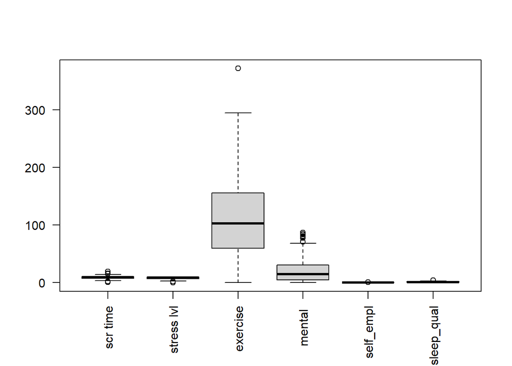

```r
#Next, we examine potential outliers using boxplots for the remaining predictors in the model

xb <- cbind(
  train_data$screen_time_hours,
  train_data$stress_level_0_10,
  train_data$exercise_minutes_per_week,
  train_data$mental_wellness_index_0_100,
  (train_data$self_employed),
  train_data$sleep_quality_1_5
)

colnames(xb) <- c("scr time", "stress lvl", "exercise", "mental ", "self_empl", "sleep_qual")

boxplot(xb,names=c("scr time", "stress lvl", "exercise", "mental ", "self_empl", "sleep_qual"),las=2)
```

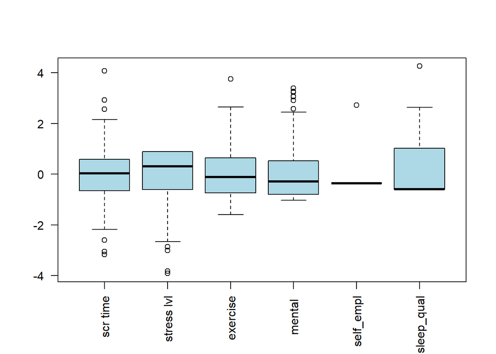

```r
xb_scaled <- scale(xb)
boxplot(xb_scaled, las=2, col="lightblue")
```

We plot boxplots to identify which independent variables contain influential outliers that may require attention or removal. We observe that this is the case for mental wellness.

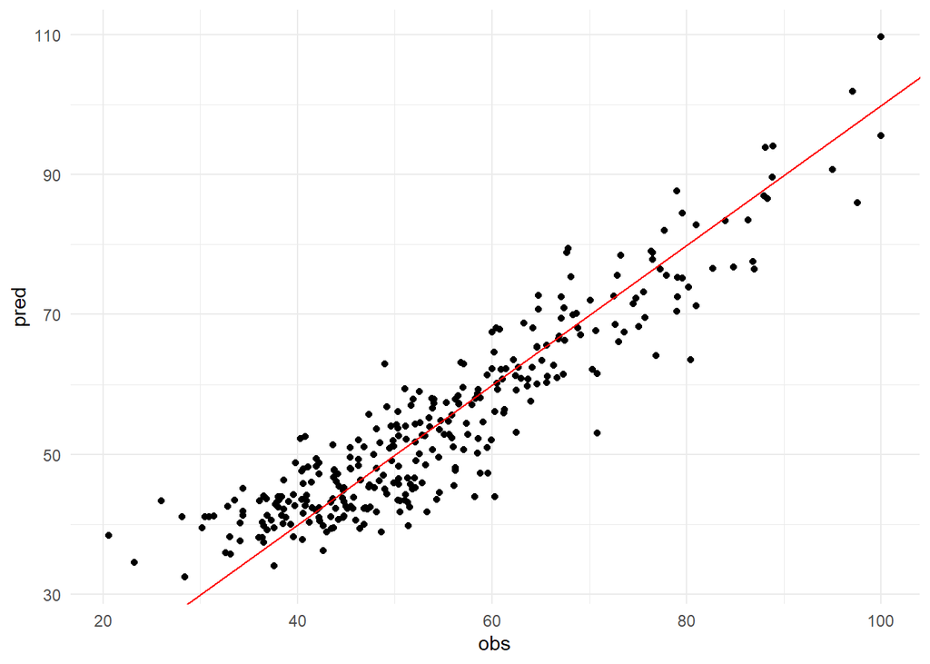

```r
#scatterplot for model 7
pred_df <- model7$pred
ggplot(pred_df, aes(x=obs, y=pred)) +
  geom_point() +
  geom_abline(slope=1, intercept=0, color="red") +
  theme_minimal()
```

We decided to include polynomial (squared) terms for mental wellness, stress level, and screen time, as their effects on productivity may not be strictly linear. For instance, very high stress might reduce productivity disproportionately, while moderate screen time could have different impacts than very low or very high values. By including squared terms, the model can better capture such non-linear relationships. The other predictors—exercise, self-employment, and sleep quality—are kept linear, as their effects are expected to be approximately linear.

Model 9

```r
#We attempt to fit a polynomial model using all the significant predictors identified so far

set.seed(123)
train_control <- trainControl(method = "cv", number = 10,savePredictions = "all")   #function from caret

# We train a linear model using cross-validation
model9 <- train(
  (productivity_0_100) ~
    mental_wellness_index_0_100 + I(mental_wellness_index_0_100^2) +
    stress_level_0_10 + I(stress_level_0_10^2) +
    screen_time_hours + I(screen_time_hours^2) +
    exercise_minutes_per_week +
    self_employed+sleep_quality_1_5,
  data = train_data,
  method = "lm",
  trControl = train_control,
  metric = "RMSE"
)
summary(model9)
```

```
##
## Call:
## lm(formula = .outcome ~ ., data = dat)
##
## Residuals:
##      Min       1Q   Median       3Q      Max
## -17.2860  -3.7996  -0.3348   3.7561  16.3923
##
## Coefficients:
##                                      Estimate Std. Error t value Pr(>|t|)
## (Intercept)                        60.9918389  5.7793382  10.553  < 2e-16 ***
## mental_wellness_index_0_100         0.3688030  0.0802623   4.595 6.29e-06 ***
## `I(mental_wellness_index_0_100^2)`  0.0003366  0.0010779   0.312  0.75502
## stress_level_0_10                  -0.0960028  1.4737244  -0.065  0.94810
## `I(stress_level_0_10^2)`           -0.1279090  0.0952798  -1.342  0.18042
## screen_time_hours                  -0.2217693  0.7326355  -0.303  0.76232
## `I(screen_time_hours^2)`           -0.0434614  0.0362453  -1.199  0.23140
## exercise_minutes_per_week          -0.0140057  0.0048757  -2.873  0.00435 **
## self_employed                       2.4594839  0.9908227   2.482  0.01358 *
## sleep_quality_1_5                   1.7873237  0.9064364   1.972  0.04951 *
## ---
## Signif. codes:  0 '***' 0.001 '**' 0.01 '*' 0.05 '.' 0.1 ' ' 1
##
## Residual standard error: 5.697 on 312 degrees of freedom
## Multiple R-squared:  0.8567, Adjusted R-squared:  0.8526
## F-statistic: 207.3 on 9 and 312 DF,  p-value: < 2.2e-16
```

```r
#Looking at the cross-validation results
model9$results
```

```
##   intercept     RMSE  Rsquared      MAE   RMSESD RsquaredSD     MAESD
## 1      TRUE 5.776151 0.8466041 4.613564 0.740783 0.04676279 0.6256609
```

Although polynomial (squared) terms were included to account for possible non-linear effects of mental wellness, stress level, and screen time, the cross-validated results (RMSE, MAE, and R²) remain almost identical to the linear model. This suggests that the relationship between these predictors and productivity is largely linear in the observed data range. As a result, adding non-linear terms does not provide a meaningful improvement in predictive performance and only increases model complexity.

```r
# applying a statistical test to detect potential outliers in the predictors

outlierTest(model7$finalModel)
```

```
## No Studentized residuals with Bonferroni p < 0.05
## Largest |rstudent|:
##       rstudent unadjusted p-value Bonferroni p
## X212 -3.146571          0.0018103      0.58293
```

Based on the metrics across these models, we conclude that Model 7 performs best in the k-fold cross-validation. We will now attempt to remove outliers from this model and compare the results.

Model 10

```r
set.seed(123)
train_control <- trainControl(method = "cv", number = 10,savePredictions = "all")   #function from caret

# We train a linear model using cross-validation
model10 <- train(
  productivity_0_100~ . -leisure_screen_hours - work_screen_hours - sleep_hours - social_hours_per_week - age - gender - work_mode - occupation + self_employed,
  data = train_data[-c(212),],
  method = "lm",
  trControl = train_control,
  metric = "RMSE"
)
summary(model10)
```

```
##
## Call:
## lm(formula = .outcome ~ ., data = dat)
##
## Residuals:
##      Min       1Q   Median       3Q      Max
## -17.0159  -3.9005  -0.2568   3.9153  17.0415
##
## Coefficients:
##                              Estimate Std. Error t value Pr(>|t|)
## (Intercept)                 69.520417   4.001879  17.372  < 2e-16 ***
## screen_time_hours           -1.083484   0.183309  -5.911 8.87e-09 ***
## sleep_quality_1_5            1.817484   0.882253   2.060  0.04022 *
## stress_level_0_10           -1.766630   0.437327  -4.040 6.74e-05 ***
## exercise_minutes_per_week   -0.014303   0.004826  -2.963  0.00328 **
## mental_wellness_index_0_100  0.384510   0.057393   6.700 9.67e-11 ***
## self_employed                2.376745   0.982469   2.419  0.01612 *
## ---
## Signif. codes:  0 '***' 0.001 '**' 0.01 '*' 0.05 '.' 0.1 ' ' 1
##
## Residual standard error: 5.654 on 314 degrees of freedom
## Multiple R-squared:  0.8557, Adjusted R-squared:  0.8529
## F-statistic: 310.3 on 6 and 314 DF,  p-value: < 2.2e-16
```

```r
#Looking at the cross-validation results
model10$results
```

```
##   intercept    RMSE  Rsquared      MAE    RMSESD RsquaredSD     MAESD
## 1      TRUE 5.72677 0.8540065 4.600799 0.4250292 0.03243417 0.3789324
```

To assess the robustness of the model, we remove a single influential observation identified in the diagnostic analysis and re-estimate the model. The results show a slight improvement in performance metrics, indicating that the model is not overly sensitive to individual data points. This suggests a reasonable level of stability and robustness in the estimated relationships.

```r
#test for multicolinearity
vif(model10$finalModel)
```

```
##           screen_time_hours           sleep_quality_1_5
##                    2.107035                    2.986064
##           stress_level_0_10   exercise_minutes_per_week
##                    8.335593                    1.128520
## mental_wellness_index_0_100               self_employed
##                   12.823070                    1.011680
```

Since the VIF function indicates multicollinearity when values exceed 5, and two of our variables show VIFs above this threshold, we need to adjust the model. We will attempt to address this by applying regularized regression to control the coefficients.

Model 11(regularization)

To address multicollinearity observed in the linear model, we apply Ridge regression, which reduces coefficient variance by shrinking correlated predictors rather than removing them. This allows us to retain all relevant variables while improving model stability.

```r
# applying Ridge regression to reduce multicollinearity
lambda_grid <- expand.grid(
  alpha  = 0,
  lambda = 10^seq(-4, 4, length = 100)
)
set.seed(123)

ridge1 <- train(
  (productivity_0_100) ~ .
    - leisure_screen_hours - work_screen_hours - sleep_hours
    - social_hours_per_week - age - gender - work_mode
    - occupation + self_employed,
  data = train_data[-c(212),],
  method = "glmnet",
  trControl = train_control,
  tuneGrid  = lambda_grid,
  metric    = "RMSE"
)

best_lambda <- ridge1$bestTune$lambda

ridge_results <- subset(
  ridge1$results,
  lambda == best_lambda
)

#We report the model performance metrics
ridge_results
```

```
##    alpha   lambda     RMSE  Rsquared      MAE    RMSESD RsquaredSD     MAESD
## 52     0 1.321941 5.753244 0.8539918 4.636957 0.4053957 0.02896826 0.3538347
```

We chose Ridge regression to address multicollinearity because it shrinks the coefficients of correlated predictors without eliminating them. Unlike Lasso, which can set some coefficients exactly to zero, Ridge allows us to retain all theoretically important predictors while improving model stability and reducing variance.

```r
#The model coefficients are now adjusted through Ridge regularization, reducing the magnitude of correlated predictors and improving stability

ridge_coef<-coef(ridge1$finalModel,s=ridge1$bestTune$lambda)
print(ridge_coef)
```

```
## 7 x 1 sparse Matrix of class "dgCMatrix"
##                              s=1.321941
## (Intercept)                 73.46379269
## screen_time_hours           -1.15796693
## sleep_quality_1_5            3.06827044
## stress_level_0_10           -2.17899044
## exercise_minutes_per_week   -0.01000934
## mental_wellness_index_0_100  0.28202406
## self_employed                2.14276072
```

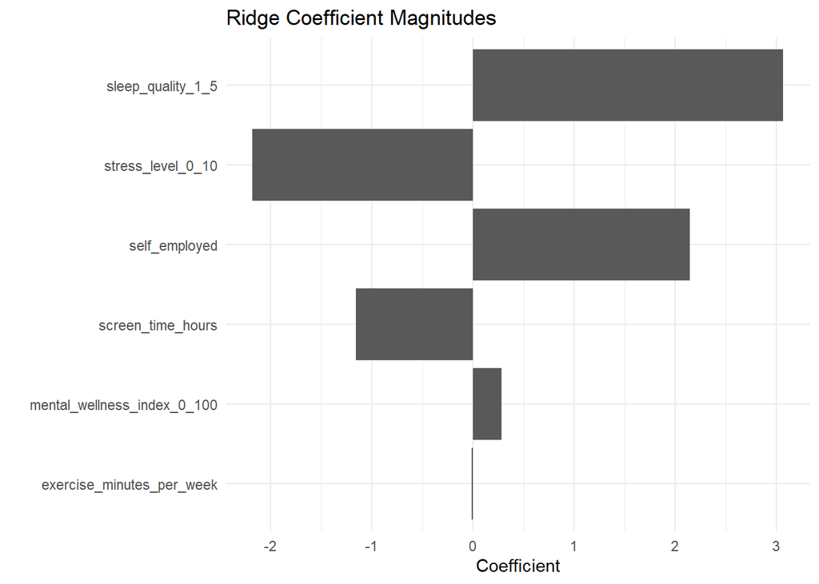

```r
coef_df <- data.frame(
  Variable = rownames(as.matrix(ridge_coef)),
  Coefficient = as.numeric(ridge_coef)
)

coef_df <- coef_df[-1, ]

ggplot(
  coef_df,
  aes(
    x = reorder(Variable, abs(Coefficient)),
    y = Coefficient
  )
) +
  geom_col() +
  coord_flip() +
  labs(
    title = "Ridge Coefficient Magnitudes",
    x = "",
    y = "Coefficient"
  ) +
  theme_minimal()
```

The Ridge regression coefficients reflect the direction of association between predictors and productivity after accounting for multicollinearity. Due to regularization, coefficient magnitudes are shrunk and should not be interpreted in the same way as in ordinary least squares regression. However, the overall pattern remains consistent: screen time and stress are negatively associated with productivity, while mental wellness, sleep quality, and self-employment show positive associations. Exercise appears to have a negligible effect. Overall, Ridge regression improves model stability by reducing the impact of correlated predictors without removing variables from the model.

Model 12 (Random Forest)

As a final benchmark, we estimate a Random Forest model using the same set of predictors retained in the previous specifications. Unlike linear and regularized regression models, Random Forest does not require the relationship between predictors and productivity to be specified in advance and can automatically capture nonlinear effects and interactions among variables. This provides an additional comparison between parametric and non-parametric machine learning approaches.

```r
library(randomForest)
set.seed(123)

train_control <- trainControl(
  method = "cv",
  number = 10,
  savePredictions = "all"
)

rf_model <- train(
  productivity_0_100 ~ .
    - leisure_screen_hours - work_screen_hours - sleep_hours
    - social_hours_per_week - age - gender - work_mode
    - occupation + self_employed,
  data = train_data[-c(212),],
  method = "rf",
  trControl = train_control,
  metric = "RMSE",
  tuneLength = 5
)

rf_model
```

```
## Random Forest
##
## 321 samples
##  14 predictor
##
## No pre-processing
## Resampling: Cross-Validated (10 fold)
## Summary of sample sizes: 289, 289, 289, 289, 288, 288, ...
## Resampling results across tuning parameters:
##
##   mtry  RMSE      Rsquared   MAE
##   2     6.218533  0.8231005  4.925490
##   3     6.228123  0.8211969  4.937910
##   4     6.250107  0.8202080  4.978688
##   5     6.264683  0.8196302  4.990926
##   6     6.299556  0.8173798  5.027326
##
## RMSE was used to select the optimal model using the smallest value.
## The final value used for the model was mtry = 2.
```

```r
rf_model$results
```

```
##   mtry     RMSE  Rsquared      MAE    RMSESD RsquaredSD     MAESD
## 1    2 6.218533 0.8231005 4.925490 0.5187274 0.04055778 0.4085139
## 2    3 6.228123 0.8211969 4.937910 0.5782826 0.04651199 0.4517892
## 3    4 6.250107 0.8202080 4.978688 0.5777515 0.04587348 0.4655224
## 4    5 6.264683 0.8196302 4.990926 0.5933439 0.04651168 0.4888345
## 5    6 6.299556 0.8173798 5.027326 0.6104111 0.04663179 0.5027319
```

The Random Forest model achieves an RMSE of approximately 6.22 and an R² of 0.823, which is slightly worse than the best-performing linear and ridge regression models. This suggests that adding nonlinear interactions and flexible tree-based structures does not improve predictive performance in this dataset.

The results indicate that the relationship between behavioral variables and productivity is largely linear within the observed range, and that simpler parametric models are sufficient for capturing the main patterns in the data.

Model comparison

```r
comparison <- data.frame(
  Model = c(
    "Model 7",
    "Model 10",
    "Model 11 (Ridge)",
    "Model 12 (Random Forest)"
  ),
  Specification = c(
    "Final linear specification",
    "Outlier-adjusted linear model",
    "Ridge regularized model",
    "Non-parametric ML benchmark"
  ),
  RMSE = c(
    5.763,
    5.727,
    5.753,
    6.219
  ),
  R2 = c(
    0.848,
    0.854,
    0.854,
    0.823
  ),
  MAE = c(
    4.637,
    4.601,
    4.637,
    4.930
  )
)

knitr::kable(
  comparison,
  digits = 3,
  caption = "Comparison of Linear, Regularized, and Non-Parametric Models"
)
```

Comparison of Linear, Regularized, and Non-Parametric Models

| Model | Specification | RMSE | R2 | MAE |
| --- | --- | --- | --- | --- |
| Model 7 | Final linear specification | 5.763 | 0.848 | 4.637 |
| Model 10 | Outlier-adjusted linear model | 5.727 | 0.854 | 4.601 |
| Model 11 (Ridge) | Ridge regularized model | 5.753 | 0.854 | 4.637 |
| Model 12 (Random Forest) | Non-parametric ML benchmark | 6.219 | 0.823 | 4.930 |

Model 10 achieved the lowest RMSE among linear specifications; however, Ridge regression was selected as the final model due to comparable predictive performance combined with improved stability under multicollinearity.

```r
#We extract the residuals from the final model

x_train <- model.matrix(
  productivity_0_100 ~ .
    - leisure_screen_hours - work_screen_hours - sleep_hours
    - social_hours_per_week - age - gender - work_mode
    - occupation + self_employed,
  data = train_data[-c(212),],
)[, -1]

y_train <- train_data[-c(212),]$productivity_0_100

y_hat <- as.numeric(
  predict(ridge1$finalModel, x_train, s = ridge1$bestTune$lambda)
)

resid <- y_train - y_hat
```

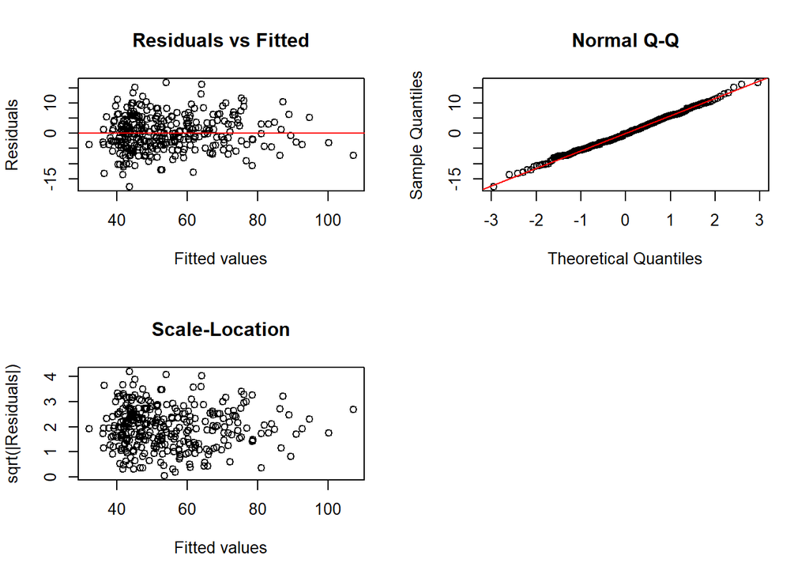

```r
# creating plots

par(mfrow = c(2, 2))

# 1. Residuals vs Fitted
plot(
  y_hat, resid,
  xlab = "Fitted values",
  ylab = "Residuals",
  main = "Residuals vs Fitted"
)
abline(h = 0, col = "red")

# 2. Normal Q-Q
qqnorm(resid, main = "Normal Q-Q")
qqline(resid, col = "red")

# 3. Scale-Location
plot(
  y_hat,
  sqrt(abs(resid)),
  xlab = "Fitted values",
  ylab = "sqrt(|Residuals|)",
  main = "Scale-Location"
)
```

The residuals versus fitted values plot appears satisfactory. There may be a slight indication of heteroskedasticity, but it is negligible and would not be corrected by simple transformations such as log or square root. Overall, the residuals are evenly distributed around zero, and the trend line is largely straight. The Q-Q plot also shows a good fit, with only minor deviations at the extremes. Similarly, the scale-location plot does not indicate any major model inadequacies. Based on these diagnostics, we are confident in proceeding to test the model on completely new data.

Final model evaluation

```r
#We will now test the best model on the test set
set.seed(123)
test_data$self_employed <- ifelse(test_data$occupation == "Self-employed", 1, 0)

x_test <- model.matrix(
  productivity_0_100 ~ . - leisure_screen_hours - work_screen_hours - sleep_hours
    - social_hours_per_week - age - gender - work_mode - occupation + self_employed,
  data = test_data
)[,-1]

pred_test <- as.numeric(
  predict(
    ridge1$finalModel,
    newx = x_test,
    s = best_lambda
  )
)

y_test<-test_data$productivity_0_100

R2_test <- 1 - sum((y_test - pred_test)^2) /
                  sum((y_test - mean(y_test))^2)

MAE<-mean(abs(y_test-pred_test))


MAPE <- mean(abs((y_test - pred_test) / y_test)) * 100
R2_test
```

```
## [1] 0.8766197
```

```r
MAE
```

```
## [1] 4.23821
```

```r
MAPE
```

```
## [1] 8.995443
```

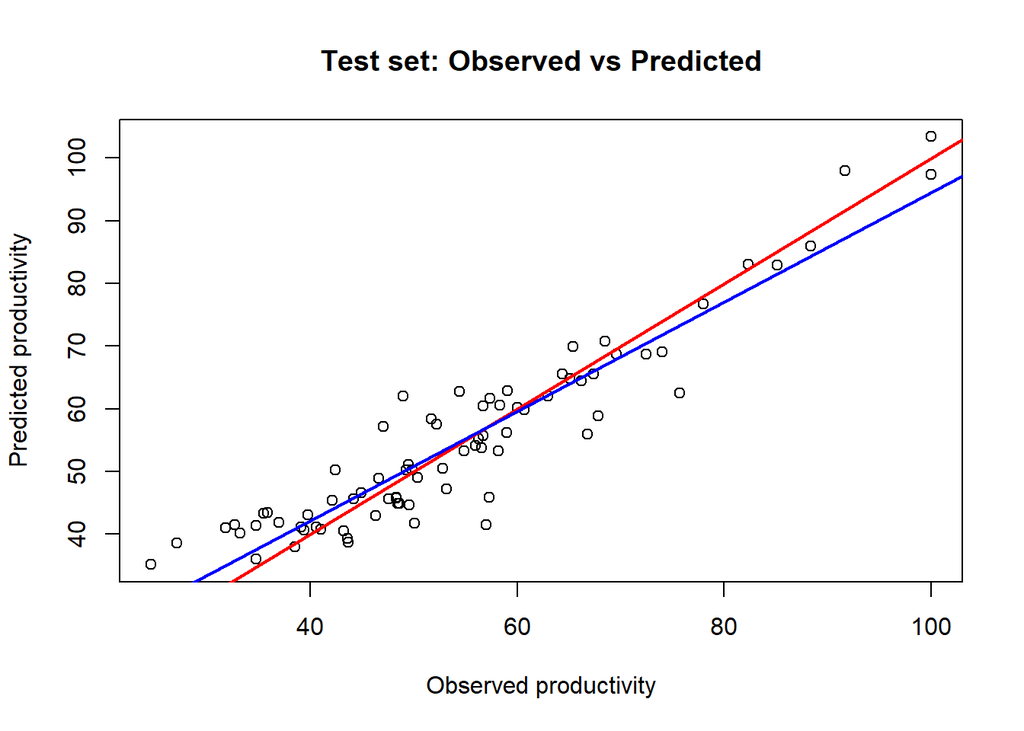

```r
plot(y_test, pred_test,
     xlab = "Observed productivity",
     ylab = "Predicted productivity",
     main = "Test set: Observed vs Predicted")

abline(a = 0, b = 1, col = "red", lwd = 2)
fit_line <- lm(pred_test ~ y_test)
abline(fit_line, col="blue", lwd=2)
```

The final ridge regression model evaluated on the independent test set achieved R² = 0.877, MAE = 4.24, and MAPE = 8.99. The performance is consistent with the cross-validation results, suggesting that the model generalizes well to unseen data without noticeable overfitting. Errors remain relatively low across both absolute and percentage-based metrics, indicating stable predictive performance across the observed range of productivity values.

Conclusion

Overall, the analysis shows that productivity can be reasonably well predicted using a relatively small set of behavioral and psychological variables. Across all models, stress level and screen time are consistently associated with lower productivity, while mental wellbeing and sleep quality show positive relationships.

The similarity between cross-validation and test performance suggests that the models generalize well and are not strongly overfitted to the training data. In particular, Ridge regression improves stability in the presence of correlated predictors without noticeably affecting predictive performance.

Overall, the results are consistent across different specifications, which increases confidence that the observed relationships are not driven by model choice or data noise.

Limitations

- The analysis is based on observational data, so findings should be interpreted as associations rather than causal effects.
- Several key variables are self-reported, which may introduce measurement error and subjective bias.
- Although multicollinearity was addressed using Ridge regression, some correlation between predictors may still affect interpretability.
- The dataset does not include external factors such as workload intensity, job characteristics, or personality traits, which may influence productivity.
- The Random Forest model was not extensively tuned, so its performance may not fully reflect its potential.